# Cleaning and Preparing data

```r
str(df6)
```

```
## 'data.frame':    531633 obs. of  13 variables:
##  $ ride_id           : chr  "C809ED75D6160B2A" "DD59FDCE0ACACAF3" "0AB83CB88C43EFC2" "7881AC6D39110C60" ...
##  $ rideable_type     : chr  "electric_bike" "electric_bike" "electric_bike" "electric_bike" ...
##  $ started_at        : chr  "2021-05-30 11:58:15" "2021-05-30 11:29:14" "2021-05-30 14:24:01" "2021-05-30 14:25:51" ...
##  $ ended_at          : chr  "2021-05-30 12:10:39" "2021-05-30 12:14:09" "2021-05-30 14:25:13" "2021-05-30 14:41:04" ...
##  $ start_station_name: chr  "" "" "" "" ...
##  $ start_station_id  : chr  "" "" "" "" ...
##  $ end_station_name  : chr  "" "" "" "" ...
##  $ end_station_id    : chr  "" "" "" "" ...
##  $ start_lat         : num  41.9 41.9 41.9 41.9 41.9 ...
##  $ start_lng         : num  -87.6 -87.6 -87.7 -87.7 -87.7 ...
##  $ end_lat           : num  41.9 41.8 41.9 41.9 41.9 ...
##  $ end_lng           : num  -87.6 -87.6 -87.7 -87.7 -87.7 ...
##  $ member_casual     : chr  "casual" "casual" "casual" "casual" ...
```

```r
str(df7)
```

```
## 'data.frame':    729595 obs. of  13 variables:
##  $ ride_id           : chr  "99FEC93BA843FB20" "06048DCFC8520CAF" "9598066F68045DF2" "B03C0FE48C412214" ...
##  $ rideable_type     : chr  "electric_bike" "electric_bike" "electric_bike" "electric_bike" ...
##  $ started_at        : chr  "2021-06-13 14:31:28" "2021-06-04 11:18:02" "2021-06-04 09:49:35" "2021-06-03 19:56:05" ...
##  $ ended_at          : chr  "2021-06-13 14:34:11" "2021-06-04 11:24:19" "2021-06-04 09:55:34" "2021-06-03 20:21:55" ...
##  $ start_station_name: chr  "" "" "" "" ...
##  $ start_station_id  : chr  "" "" "" "" ...
##  $ end_station_name  : chr  "" "" "" "" ...
##  $ end_station_id    : chr  "" "" "" "" ...
##  $ start_lat         : num  41.8 41.8 41.8 41.8 41.8 ...
##  $ start_lng         : num  -87.6 -87.6 -87.6 -87.6 -87.6 ...
##  $ end_lat           : num  41.8 41.8 41.8 41.8 41.8 ...
##  $ end_lng           : num  -87.6 -87.6 -87.6 -87.6 -87.6 ...
##  $ member_casual     : chr  "member" "member" "member" "member" ...
```

```r
str(df8)
```

```
## 'data.frame':    822410 obs. of  13 variables:
##  $ ride_id           : chr  "0A1B623926EF4E16" "B2D5583A5A5E76EE" "6F264597DDBF427A" "379B58EAB20E8AA5" ...
##  $ rideable_type     : chr  "docked_bike" "classic_bike" "classic_bike" "classic_bike" ...
##  $ started_at        : chr  "2021-07-02 14:44:36" "2021-07-07 16:57:42" "2021-07-25 11:30:55" "2021-07-08 22:08:30" ...
##  $ ended_at          : chr  "2021-07-02 15:19:58" "2021-07-07 17:16:09" "2021-07-25 11:48:45" "2021-07-08 22:23:32" ...
##  $ start_station_name: chr  "Michigan Ave & Washington St" "California Ave & Cortez St" "Wabash Ave & 16th St" "California Ave & Cortez St" ...
##  $ start_station_id  : chr  "13001" "17660" "SL-012" "17660" ...
##  $ end_station_name  : chr  "Halsted St & North Branch St" "Wood St & Hubbard St" "Rush St & Hubbard St" "Carpenter St & Huron St" ...
##  $ end_station_id    : chr  "KA1504000117" "13432" "KA1503000044" "13196" ...
##  $ start_lat         : num  41.9 41.9 41.9 41.9 41.9 ...
##  $ start_lng         : num  -87.6 -87.7 -87.6 -87.7 -87.7 ...
##  $ end_lat           : num  41.9 41.9 41.9 41.9 41.9 ...
##  $ end_lng           : num  -87.6 -87.7 -87.6 -87.7 -87.7 ...
##  $ member_casual     : chr  "casual" "casual" "member" "member" ...
```

```r
str(df9)
```

```
## 'data.frame':    804352 obs. of  13 variables:
##  $ ride_id           : chr  "99103BB87CC6C1BB" "EAFCCCFB0A3FC5A1" "9EF4F46C57AD234D" "5834D3208BFAF1DA" ...
##  $ rideable_type     : chr  "electric_bike" "electric_bike" "electric_bike" "electric_bike" ...
##  $ started_at        : chr  "2021-08-10 17:15:49" "2021-08-10 17:23:14" "2021-08-21 02:34:23" "2021-08-21 06:52:55" ...
##  $ ended_at          : chr  "2021-08-10 17:22:44" "2021-08-10 17:39:24" "2021-08-21 02:50:36" "2021-08-21 07:08:13" ...
##  $ start_station_name: chr  "" "" "" "" ...
##  $ start_station_id  : chr  "" "" "" "" ...
##  $ end_station_name  : chr  "" "" "" "" ...
##  $ end_station_id    : chr  "" "" "" "" ...
##  $ start_lat         : num  41.8 41.8 42 42 41.8 ...
##  $ start_lng         : num  -87.7 -87.7 -87.7 -87.7 -87.6 ...
##  $ end_lat           : num  41.8 41.8 42 42 41.8 ...
##  $ end_lng           : num  -87.7 -87.6 -87.7 -87.7 -87.6 ...
##  $ member_casual     : chr  "member" "member" "member" "member" ...
```

```r
str(df10)
```

```
## 'data.frame':    756147 obs. of  13 variables:
##  $ ride_id           : chr  "9DC7B962304CBFD8" "F930E2C6872D6B32" "6EF72137900BB910" "78D1DE133B3DBF55" ...
##  $ rideable_type     : chr  "electric_bike" "electric_bike" "electric_bike" "electric_bike" ...
##  $ started_at        : chr  "2021-09-28 16:07:10" "2021-09-28 14:24:51" "2021-09-28 00:20:16" "2021-09-28 14:51:17" ...
##  $ ended_at          : chr  "2021-09-28 16:09:54" "2021-09-28 14:40:05" "2021-09-28 00:23:57" "2021-09-28 15:00:06" ...
##  $ start_station_name: chr  "" "" "" "" ...
##  $ start_station_id  : chr  "" "" "" "" ...
##  $ end_station_name  : chr  "" "" "" "" ...
##  $ end_station_id    : chr  "" "" "" "" ...
##  $ start_lat         : num  41.9 41.9 41.8 41.8 41.9 ...
##  $ start_lng         : num  -87.7 -87.6 -87.7 -87.7 -87.7 ...
##  $ end_lat           : num  41.9 42 41.8 41.8 41.9 ...
##  $ end_lng           : num  -87.7 -87.7 -87.7 -87.7 -87.7 ...
##  $ member_casual     : chr  "casual" "casual" "casual" "casual" ...
```

```r
str(df11)
```

```
## 'data.frame':    631226 obs. of  13 variables:
##  $ ride_id           : chr  "620BC6107255BF4C" "4471C70731AB2E45" "26CA69D43D15EE14" "362947F0437E1514" ...
##  $ rideable_type     : chr  "electric_bike" "electric_bike" "electric_bike" "electric_bike" ...
##  $ started_at        : chr  "2021-10-22 12:46:42" "2021-10-21 09:12:37" "2021-10-16 16:28:39" "2021-10-16 16:17:48" ...
##  $ ended_at          : chr  "2021-10-22 12:49:50" "2021-10-21 09:14:14" "2021-10-16 16:36:26" "2021-10-16 16:19:03" ...
##  $ start_station_name: chr  "Kingsbury St & Kinzie St" "" "" "" ...
##  $ start_station_id  : chr  "KA1503000043" "" "" "" ...
##  $ end_station_name  : chr  "" "" "" "" ...
##  $ end_station_id    : chr  "" "" "" "" ...
##  $ start_lat         : num  41.9 41.9 41.9 41.9 41.9 ...
##  $ start_lng         : num  -87.6 -87.7 -87.7 -87.7 -87.7 ...
##  $ end_lat           : num  41.9 41.9 41.9 41.9 41.9 ...
##  $ end_lng           : num  -87.6 -87.7 -87.7 -87.7 -87.7 ...
##  $ member_casual     : chr  "member" "member" "member" "member" ...
```

```r
str(df12)
```

```
## 'data.frame':    359978 obs. of  13 variables:
##  $ ride_id           : chr  "7C00A93E10556E47" "90854840DFD508BA" "0A7D10CDD144061C" "2F3BE33085BCFF02" ...
##  $ rideable_type     : chr  "electric_bike" "electric_bike" "electric_bike" "electric_bike" ...
##  $ started_at        : chr  "2021-11-27 13:27:38" "2021-11-27 13:38:25" "2021-11-26 22:03:34" "2021-11-27 09:56:49" ...
##  $ ended_at          : chr  "2021-11-27 13:46:38" "2021-11-27 13:56:10" "2021-11-26 22:05:56" "2021-11-27 10:01:50" ...
##  $ start_station_name: chr  "" "" "" "" ...
##  $ start_station_id  : chr  "" "" "" "" ...
##  $ end_station_name  : chr  "" "" "" "" ...
##  $ end_station_id    : chr  "" "" "" "" ...
##  $ start_lat         : num  41.9 42 42 41.9 41.9 ...
##  $ start_lng         : num  -87.7 -87.7 -87.7 -87.8 -87.6 ...
##  $ end_lat           : num  42 41.9 42 41.9 41.9 ...
##  $ end_lng           : num  -87.7 -87.7 -87.7 -87.8 -87.6 ...
##  $ member_casual     : chr  "casual" "casual" "casual" "casual" ...
```

From the structure I see that all 12 csvs have common attributes.

```r
# Merge all the data frames into one big data frame.
bike_trips <- rbind(df1,df2, df3, df4, df5, df6, df7, df8, df9, df10,
                    df11, df12)
# Check structure of the combined data frame and take a glimpse at it.
str(bike_trips)
```

```
## 'data.frame':    5479096 obs. of  13 variables:
##  $ ride_id           : chr  "70B6A9A437D4C30D" "158A465D4E74C54A" "5262016E0F1F2F9A" "BE119628E44F871E" ...
##  $ rideable_type     : chr  "classic_bike" "electric_bike" "electric_bike" "electric_bike" ...
##  $ started_at        : chr  "2020-12-27 12:44:29" "2020-12-18 17:37:15" "2020-12-15 15:04:33" "2020-12-15 15:54:18" ...
##  $ ended_at          : chr  "2020-12-27 12:55:06" "2020-12-18 17:44:19" "2020-12-15 15:11:28" "2020-12-15 16:00:11" ...
##  $ start_station_name: chr  "Aberdeen St & Jackson Blvd" "" "" "" ...
##  $ start_station_id  : chr  "13157" "" "" "" ...
##  $ end_station_name  : chr  "Desplaines St & Kinzie St" "" "" "" ...
##  $ end_station_id    : chr  "TA1306000003" "" "" "" ...
##  $ start_lat         : num  41.9 41.9 41.9 41.9 41.8 ...
##  $ start_lng         : num  -87.7 -87.7 -87.7 -87.7 -87.6 ...
##  $ end_lat           : num  41.9 41.9 41.9 41.9 41.8 ...
##  $ end_lng           : num  -87.6 -87.7 -87.7 -87.7 -87.6 ...
##  $ member_casual     : chr  "member" "member" "member" "member" ...
```

```r
view(head(bike_trips, 500))
```

##### Manipulate data

```r
# Convert Data/Time stamp to Date/time. Add columns that list the date, month, day, and year of each ride
# This will allow us to aggregate ride data for each month, day, or year.
bike_trips$date <- as.Date(bike_trips$started_at)
bike_trips$month <- format(as.Date(bike_trips$date), "%B")
bike_trips$day <- format(as.Date(bike_trips$date), "%d")
bike_trips$year <- format(as.Date(bike_trips$date), "%Y")
bike_trips$day_of_week <- weekdays(bike_trips$date)
```

```r
# Creating a column called "ride_length" by subtracting "started_at" from "ended at".
bike_trips$ride_length <- difftime(bike_trips$ended_at, bike_trips$started_at, units = "mins")

#inspect the structure of the new column.
str(bike_trips)
```

```
## 'data.frame':    5479096 obs. of  19 variables:
##  $ ride_id           : chr  "70B6A9A437D4C30D" "158A465D4E74C54A" "5262016E0F1F2F9A" "BE119628E44F871E" ...
##  $ rideable_type     : chr  "classic_bike" "electric_bike" "electric_bike" "electric_bike" ...
##  $ started_at        : chr  "2020-12-27 12:44:29" "2020-12-18 17:37:15" "2020-12-15 15:04:33" "2020-12-15 15:54:18" ...
##  $ ended_at          : chr  "2020-12-27 12:55:06" "2020-12-18 17:44:19" "2020-12-15 15:11:28" "2020-12-15 16:00:11" ...
##  $ start_station_name: chr  "Aberdeen St & Jackson Blvd" "" "" "" ...
##  $ start_station_id  : chr  "13157" "" "" "" ...
##  $ end_station_name  : chr  "Desplaines St & Kinzie St" "" "" "" ...
##  $ end_station_id    : chr  "TA1306000003" "" "" "" ...
##  $ start_lat         : num  41.9 41.9 41.9 41.9 41.8 ...
##  $ start_lng         : num  -87.7 -87.7 -87.7 -87.7 -87.6 ...
##  $ end_lat           : num  41.9 41.9 41.9 41.9 41.8 ...
##  $ end_lng           : num  -87.6 -87.7 -87.7 -87.7 -87.6 ...
##  $ member_casual     : chr  "member" "member" "member" "member" ...
##  $ date              : Date, format: "2020-12-27" "2020-12-18" ...
##  $ month             : chr  "December" "December" "December" "December" ...
##  $ day               : chr  "27" "18" "15" "15" ...
##  $ year              : chr  "2020" "2020" "2020" "2020" ...
##  $ day_of_week       : chr  "Sunday" "Friday" "Tuesday" "Tuesday" ...
##  $ ride_length       : 'difftime' num  10.6166666666667 7.06666666666667 6.91666666666667 5.88333333333333 ...
##   ..- attr(*, "units")= chr "mins"
```

```r
# Convert "ride_length" from Factor to numeric so we can run calculations on the data and
# rounding it off to 4 decimal places.
is.factor(bike_trips$ride_length)
```

```
## [1] FALSE
```

```r
bike_trips$ride_length <- as.numeric(as.character(bike_trips$ride_length))
is.numeric(bike_trips$ride_length)
```

```
## [1] TRUE
```

```r
bike_trips$ride_length <- round(bike_trips$ride_length, 4)
```

```r
# Remove ride_length that are less than 0. This means all negatives.
bike_trips <- filter(bike_trips, ride_length > 0)
```

```r
#Check member_casual, rideable_type and month columns to see if there are any discrepancies on the type of rider and bike type.

unique(bike_trips$member_casual)
```

```
## [1] "member" "casual"
```

```r
unique(bike_trips$rideable_type)
```

```
## [1] "classic_bike"  "electric_bike" "docked_bike"
```

```r
unique(bike_trips$month)
```

```
##  [1] "December"  "January"   "February"  "March"     "April"     "May"
##  [7] "June"      "July"      "August"    "September" "October"   "November"
```

```r
# Remove observations with NA.
bike_trips <- drop_na(bike_trips)
view(head(bike_trips, 500))
```

```r
# Remove unwanted columns from the data for analysis
colnames(bike_trips)
```

```
##  [1] "ride_id"            "rideable_type"      "started_at"
##  [4] "ended_at"           "start_station_name" "start_station_id"
##  [7] "end_station_name"   "end_station_id"     "start_lat"
## [10] "start_lng"          "end_lat"            "end_lng"
## [13] "member_casual"      "date"               "month"
## [16] "day"                "year"               "day_of_week"
## [19] "ride_length"
```

```r
bike_trips <- bike_trips %>%
  select(-c(start_lat, start_lng, end_lat, end_lng, start_station_id, start_station_name,
            end_station_id, end_station_name))
str(bike_trips)
```

```
## 'data.frame':    5473287 obs. of  11 variables:
##  $ ride_id      : chr  "70B6A9A437D4C30D" "158A465D4E74C54A" "5262016E0F1F2F9A" "BE119628E44F871E" ...
##  $ rideable_type: chr  "classic_bike" "electric_bike" "electric_bike" "electric_bike" ...
##  $ started_at   : chr  "2020-12-27 12:44:29" "2020-12-18 17:37:15" "2020-12-15 15:04:33" "2020-12-15 15:54:18" ...
##  $ ended_at     : chr  "2020-12-27 12:55:06" "2020-12-18 17:44:19" "2020-12-15 15:11:28" "2020-12-15 16:00:11" ...
##  $ member_casual: chr  "member" "member" "member" "member" ...
##  $ date         : Date, format: "2020-12-27" "2020-12-18" ...
##  $ month        : chr  "December" "December" "December" "December" ...
##  $ day          : chr  "27" "18" "15" "15" ...
##  $ year         : chr  "2020" "2020" "2020" "2020" ...
##  $ day_of_week  : chr  "Sunday" "Friday" "Tuesday" "Tuesday" ...
##  $ ride_length  : num  10.62 7.07 6.92 5.88 2.7 ...
```

```r
# Arrange the day_of_week and months column accordingly
bike_trips$day_of_week <- ordered(bike_trips$day_of_week, levels=c("Sunday", "Monday", "Tuesday", "Wednesday", "Thursday", "Friday", "Saturday"))
bike_trips$month <- ordered(bike_trips$month, levels=c("January", "February", "March", "April", "May", "June", "July", "August", "September", "October", "November", "December"))
```

### CONDUCTING DESCRIPTIVE STATISTICS

```r
#Find the overall ride_lenth min, max, mean and median by rider type. Remember ride_length is in minutes
summary(bike_trips$ride_length)
```

```
##     Min.  1st Qu.   Median     Mean  3rd Qu.     Max.
##     0.02     6.82    12.12    21.18    21.97 55944.15
```

```r
# Compare members and casual users
bike_trips %>%
  group_by(member_casual) %>%
  summarise(avg_ride_lenth = mean(ride_length), median_ride_length = median(ride_length), max_ride_length = max(ride_length), min_ride_length = min(ride_length))
```

```
## # A tibble: 2 × 5
##   member_casual avg_ride_lenth median_ride_length max_ride_length min_ride_len…¹
##   <chr>                  <dbl>              <dbl>           <dbl>          <dbl>
## 1 casual                  30.4              16.1           55944.         0.0167
## 2 member                  13.5               9.72           1500.         0.0167
## # … with abbreviated variable name ¹min_ride_length
```

```r
# See the average ride time by each day for members vs casual users
aggregate(bike_trips$ride_length ~ bike_trips$member_casual + bike_trips$day_of_week, FUN = mean)
```

```
##    bike_trips$member_casual bike_trips$day_of_week bike_trips$ride_length
## 1                    casual                 Sunday               35.53930
## 2                    member                 Sunday               15.35205
## 3                    casual                 Monday               30.47992
## 4                    member                 Monday               13.04165
## 5                    casual                Tuesday               26.78096
## 6                    member                Tuesday               12.63705
## 7                    casual              Wednesday               26.33382
## 8                    member              Wednesday               12.78006
## 9                    casual               Thursday               26.21736
## 10                   member               Thursday               12.67849
## 11                   casual                 Friday               28.86747
## 12                   member                 Friday               13.18166
## 13                   casual               Saturday               32.97599
## 14                   member               Saturday               15.02284
```

```r
# analyze ridership data by type of rider and day of the week
bike_trips %>%
  mutate(weekday = lubridate :: wday(started_at, label = TRUE)) %>%
  group_by(member_casual, weekday) %>%
  summarise(number_of_rides = n(), average_duration = mean(ride_length)) %>%
  arrange(member_casual, weekday)
```

```
## # A tibble: 14 × 4
## # Groups:   member_casual [2]
##    member_casual weekday number_of_rides average_duration
##    <chr>         <ord>             <int>            <dbl>
##  1 casual        Sun              476993             35.5
##  2 casual        Mon              281794             30.5
##  3 casual        Tue              271771             26.8
##  4 casual        Wed              272499             26.3
##  5 casual        Thu              277780             26.2
##  6 casual        Fri              354068             28.9
##  7 casual        Sat              550623             33.0
##  8 member        Sun              372288             15.4
##  9 member        Mon              407409             13.0
## 10 member        Tue              460302             12.6
## 11 member        Wed              460560             12.8
## 12 member        Thu              432877             12.7
## 13 member        Fri              429089             13.2
## 14 member        Sat              425234             15.0
```

### VISUALIZATION OF THE DATA

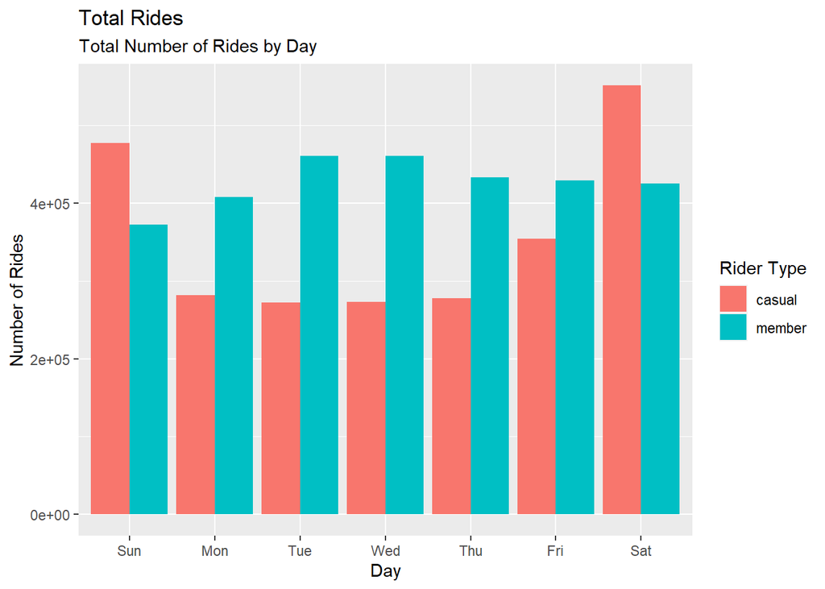

```r
bike_trips %>%
  mutate(weekday = lubridate :: wday(started_at, label = TRUE)) %>%
  group_by(member_casual, weekday) %>%
  summarise(number_of_rides = n(), average_duration = mean(ride_length)) %>%
  arrange(member_casual, weekday) %>%
  ggplot(mapping = aes(x = weekday, y = number_of_rides, fill = member_casual)) +
  geom_col(position = "dodge") + labs(title = "Total Rides",
                                      subtitle = "Total Number of Rides by Day",
                                      x = "Day",
                                      y = "Number of Rides",
                                      fill = "Rider Type")
```

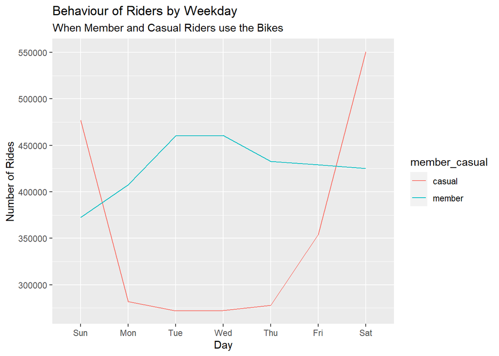

```r
# I visualized the total number of rides in a line graph to clearly see when the number of rides increased and decreased During the Weekday between the two types of riders
bike_trips %>%
  mutate(weekday = lubridate :: wday(started_at, label = TRUE)) %>%
  group_by(member_casual, weekday) %>%
  summarise(number_of_rides = n(), average_duration = mean(ride_length)) %>%
  arrange(member_casual, weekday) %>%
  ggplot(mapping = aes(x = weekday, y = number_of_rides, fill = member_casual)) +
  geom_line(mapping = aes(x = weekday, y = number_of_rides, color = member_casual, group = member_casual)) +
  labs(title = "Behaviour of Riders by Weekday",
       subtitle = "When Member and Casual Riders use the Bikes",
       x = "Day",
       y = "Number of Rides",
       fill = "Rider Type")
```

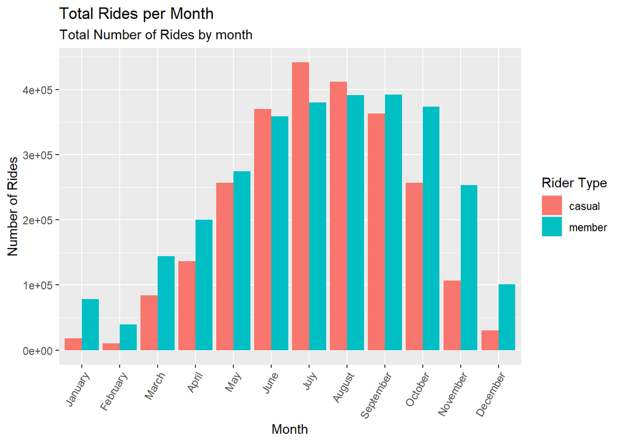

```r
# Visualizing how riding habits change throughout the year using column charts.
bike_trips %>%
  mutate(weekday = lubridate :: wday(started_at, label = TRUE)) %>%
  group_by(member_casual, month) %>%
  summarise(number_of_rides = n(), average_duration = mean(ride_length)) %>%
  arrange(member_casual, month) %>%
  ggplot(mapping = aes(x = month, y = number_of_rides, fill = member_casual)) +
  geom_col(position = "dodge") + labs(title = "Total Rides per Month",
                                      subtitle = "Total Number of Rides by month",
                                      x = "Month",
                                      y = "Number of Rides",
                                      fill = "Rider Type") +
  theme(axis.text.x = element_text(angle = 60, hjust = 1))
```

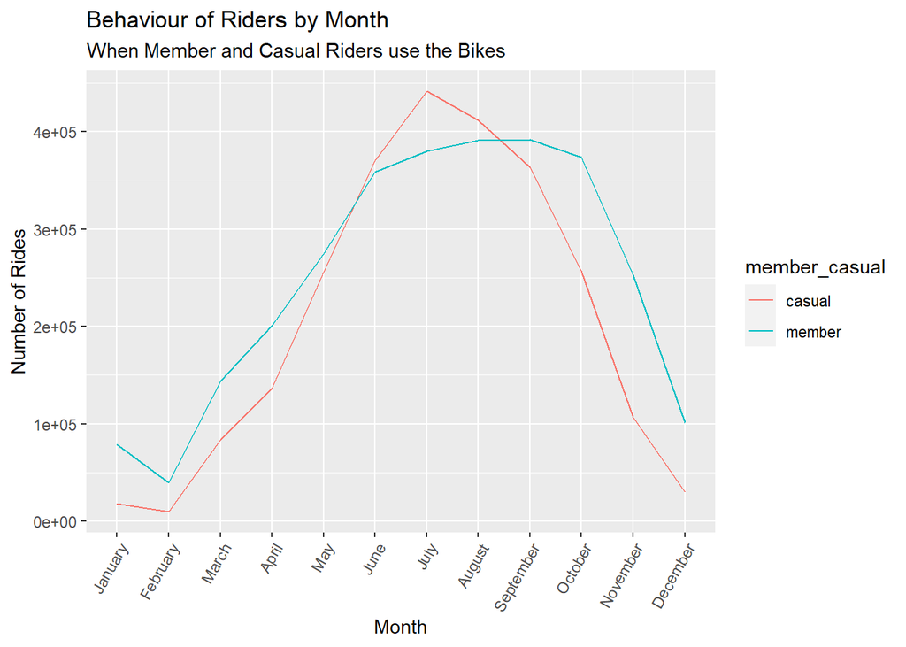

```r
# Visualizing how riding habits change throughout the year using line chart to clearly see when the number of rides increased and decreased During the Weekday between the two types of riders
bike_trips %>%
  mutate(weekday = lubridate :: wday(started_at, label = TRUE)) %>%
  group_by(member_casual, month) %>%
  summarise(number_of_rides = n(), average_duration = mean(ride_length)) %>%
  arrange(member_casual, month) %>%
  ggplot(mapping = aes(x = month, y = number_of_rides, fill = member_casual)) +
  geom_line(mapping = aes(x = month, y = number_of_rides, color = member_casual, group = member_casual)) +
  labs(title = "Behaviour of Riders by Month",
       subtitle = "When Member and Casual Riders use the Bikes",
       x = "Month",
       y = "Number of Rides",
       fill = "Rider Type") +
  theme(axis.text.x = element_text(angle = 60, hjust = 1))
```

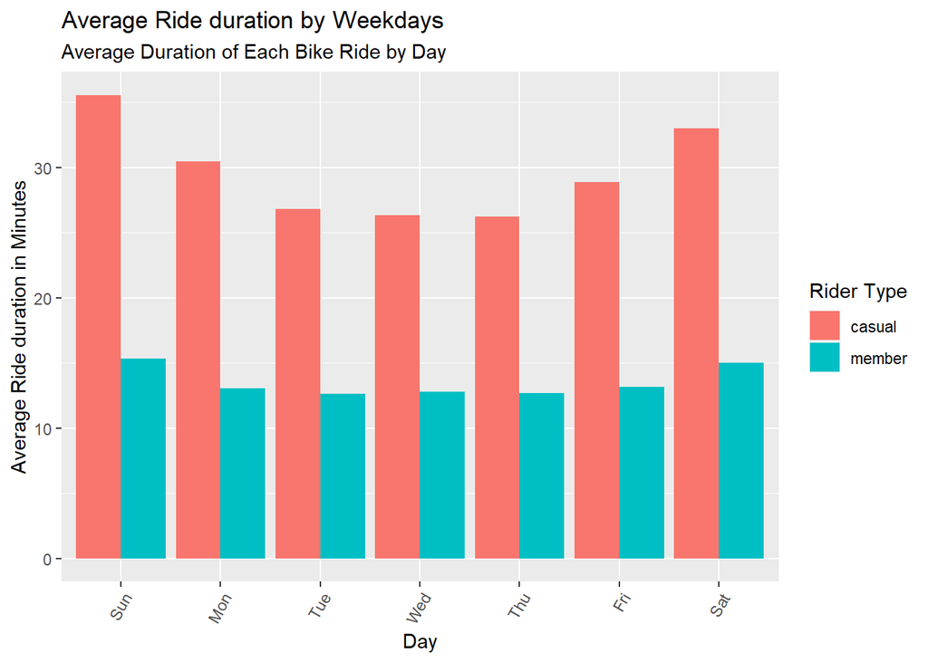

```r
bike_trips %>%
  mutate(weekday = lubridate :: wday(started_at, label = TRUE)) %>%
  group_by(member_casual, weekday) %>%
  summarise(number_of_rides = n(), average_duration = mean(ride_length)) %>%
  arrange(member_casual, weekday) %>%
  ggplot(mapping = aes(x = weekday, y = average_duration, fill = member_casual)) +
  geom_col(position = "dodge") + labs(title = "Average Ride duration by Weekdays",
                                      subtitle = "Average Duration of Each Bike Ride by Day",
                                      x = "Day",
                                      y = "Average Ride duration in Minutes",
                                      fill = "Rider Type") +
  theme(axis.text.x = element_text(angle = 60, hjust = 1))
```

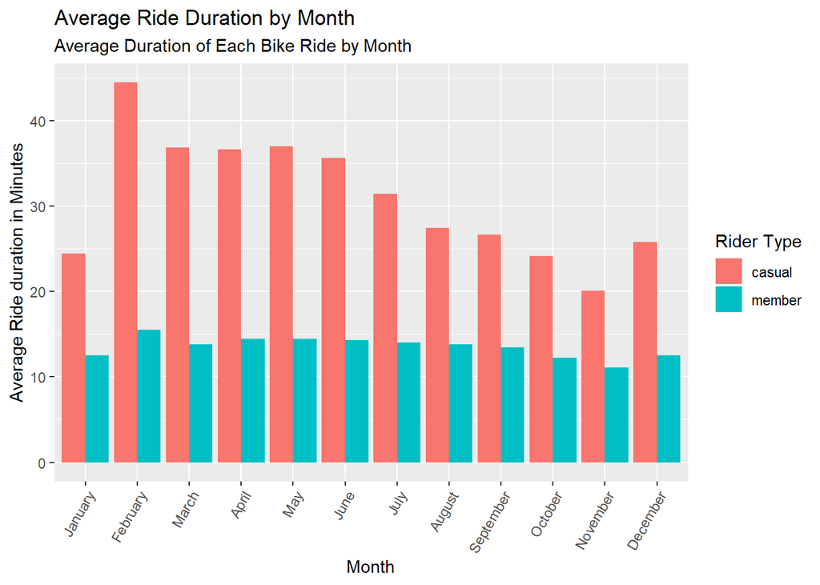

```r
bike_trips %>%
  mutate(weekday = lubridate :: wday(started_at, label = TRUE)) %>%
  group_by(member_casual, month) %>%
  summarise(number_of_rides = n(), average_duration = mean(ride_length)) %>%
  arrange(member_casual, month) %>%
  ggplot(mapping = aes(x = month, y = average_duration, fill = member_casual)) +
  geom_col(position = "dodge") + labs(title = "Average Ride Duration by Month",
                                      subtitle = "Average Duration of Each Bike Ride by Month",
                                      x = "Month",
                                      y = "Average Ride duration in Minutes",
                                      fill = "Rider Type") +
  theme(axis.text.x = element_text(angle = 60, hjust = 1))
```

Calculate percentage of concentration of casual riders on weekends compared with the total of the whole week. Also Calculate percentage proportion of casual riders in all seasons, finally, the summer, winter, spring and Autumn weekends and visualize the findings in a pie chart.

```r
# 1st step: Calculate total Casual riders
CasualRide_mins_Total  <- bike_trips %>%
 filter(member_casual == "casual") %>%
  summarise(n())
CasualRide_mins_Total
```

```
##       n()
## 1 2485528
```

```r
# 2nd Step: Calculate number of casual riders in the summer, winter, spring and Autumn.
CasualRide_mins_Summer <- bike_trips %>%
  filter(member_casual == "casual" & (month == "June" | month == "July" | month == "August" | month == "September")) %>%
  summarise(n())
CasualRide_mins_Summer
```

```
##       n()
## 1 1587003
```

```r
CasualRide_mins_Winter <- bike_trips %>%
  filter(member_casual == "casual" & (month == "December" | month == "January" | month == "February" | month == "March")) %>%
  summarise(n())
CasualRide_mins_Winter
```

```
##      n()
## 1 142045
```

```r
CasualRide_mins_Spring <- bike_trips %>%
  filter(member_casual == "casual" & (month == "April" | month == "May")) %>%
  summarise(n())
CasualRide_mins_Spring
```

```
##      n()
## 1 392952
```

```r
CasualRide_mins_Autumn <- bike_trips %>%
  filter(member_casual == "casual" & (month == "October" | month == "November")) %>%
  summarise(n())
CasualRide_mins_Autumn
```

```
##      n()
## 1 363528
```

```r
#3rd Step: Calculate the percentage of casual riders in the summer, winter, spring and autumn
Casualsummer_ride_perc = 100*CasualRide_mins_Summer/CasualRide_mins_Total
print(paste0("Casual ride in summer % = ", Casualsummer_ride_perc))
```

```
## [1] "Casual ride in summer % = 63.8497333363374"
```

```r
Casualwinter_ride_perc = 100*CasualRide_mins_Winter/CasualRide_mins_Total
print(paste0("Casual ride in winter % = ", Casualwinter_ride_perc))
```

```
## [1] "Casual ride in winter % = 5.7148823107203"
```

```r
CasualSpring_ride_perc = 100*CasualRide_mins_Spring/CasualRide_mins_Total
print(paste0("Casual ride in spring % = ", CasualSpring_ride_perc))
```

```
## [1] "Casual ride in spring % = 15.8095986044012"
```

```r
CasualAutumn_ride_perc = 100*CasualRide_mins_Autumn/CasualRide_mins_Total
print(paste0("Casual ride in autumn % = ", CasualAutumn_ride_perc))
```

```
## [1] "Casual ride in autumn % = 14.6257857485412"
```

```r
# PART TWO
# Total Casual Rides in The weekend
CasualRide_mins_Weekend <- bike_trips %>%
  filter(member_casual == "casual") %>%
  filter(day_of_week == "Saturday" | day_of_week == "Sunday") %>%
  summarise(n())
CasualRide_mins_Weekend
```

```
##       n()
## 1 1027616
```

```r
Casualweekend_ride_perc = 100*CasualRide_mins_Weekend/CasualRide_mins_Total
print(paste0("Casual weekend ride % = ", Casualweekend_ride_perc))
```

```
## [1] "Casual weekend ride % = 41.3439719850269"
```

```r
# Casual Rides in the weekends of Summer season
CasualRide_mins_SummerWeekend <- bike_trips %>%
  filter(member_casual == "casual"& (month == "June" | month == "July" | month == "August" | month == "September")) %>%
  filter(day_of_week == "Saturday" | day_of_week == "Sunday") %>%
  summarise(n())
Casualweekend_ride_summer_perc = 100*CasualRide_mins_SummerWeekend/CasualRide_mins_Weekend
print(paste0("Casual weekend ride during summer % = ", Casualweekend_ride_summer_perc))
```

```
## [1] "Casual weekend ride during summer % = 61.2760019306823"
```

```r
# Casual Rides in the weekends of Winter season
CasualRide_mins_WinterWeekend <- bike_trips %>%
  filter(member_casual == "casual"& (month == "December" | month == "January" | month == "February" | month == "March")) %>%
  filter(day_of_week == "Saturday" | day_of_week == "Sunday") %>%
  summarise(n())
Casualweekend_ride_Winter_perc = 100*CasualRide_mins_WinterWeekend/CasualRide_mins_Weekend
print(paste0("Casual weekend ride during Winter % = ", Casualweekend_ride_Winter_perc))
```

```
## [1] "Casual weekend ride during Winter % = 5.91290910223274"
```

```r
# Casual Rides in the weekends of spring season
CasualRide_mins_springWeekend <- bike_trips %>%
  filter(member_casual == "casual"& (month == "April" | month == "May")) %>%
  filter(day_of_week == "Saturday" | day_of_week == "Sunday") %>%
  summarise(n())
Casualweekend_ride_spring_perc = 100*CasualRide_mins_springWeekend/CasualRide_mins_Weekend
print(paste0("Casual weekend ride during spring % = ", Casualweekend_ride_spring_perc))
```

```
## [1] "Casual weekend ride during spring % = 17.5295051848161"
```

```r
# Casual Rides in the weekends of Autumn season
CasualRide_mins_AutumnWeekend <- bike_trips %>%
  filter(member_casual == "casual"& (month == "October" | month == "November")) %>%
  filter(day_of_week == "Saturday" | day_of_week == "Sunday") %>%
  summarise(n())
Casualweekend_ride_Autumn_perc = 100*CasualRide_mins_AutumnWeekend/CasualRide_mins_Weekend
print(paste0("Casual weekend ride during Autumn % = ", Casualweekend_ride_Autumn_perc))
```

```
## [1] "Casual weekend ride during Autumn % = 15.2815837822689"
```

```r
# 1st step: Calculate total member riders
MemberRide_Total  <- bike_trips %>%
 filter(member_casual == "member") %>%
  summarise(n())
MemberRide_Total
```

```
##       n()
## 1 2987759
```

```r
# 2nd Step: Calculate number of member riders in the summer, winter, spring and Autumn.
MemberRide_Summer <- bike_trips %>%
  filter(member_casual == "member" & (month == "June" | month == "July" | month == "August" | month == "September")) %>%
  summarise(n())
MemberRide_Summer
```

```
##       n()
## 1 1522390
```

```r
MemberRide_Winter <- bike_trips %>%
  filter(member_casual == "member" & (month == "December" | month == "January" | month == "February" | month == "March")) %>%
  summarise(n())
MemberRide_Winter
```

```
##      n()
## 1 363424
```

```r
MemberRide_Spring <- bike_trips %>%
  filter(member_casual == "member" & (month == "April" | month == "May")) %>%
  summarise(n())
MemberRide_Spring
```

```
##      n()
## 1 475100
```

```r
MemberRide_Autumn <- bike_trips %>%
  filter(member_casual == "member" & (month == "October" | month == "November")) %>%
  summarise(n())
MemberRide_Autumn
```

```
##      n()
## 1 626845
```

```r
#3rd Step: Calculate the percentage of member riders in the summer, winter, spring and autumn
Membersummer_ride_perc = 100*MemberRide_Summer/MemberRide_Total
print(paste0("Member ride in summer % = ", Membersummer_ride_perc))
```

```
## [1] "Member ride in summer % = 50.9542436321002"
```

```r
Memberwinter_ride_perc = 100*MemberRide_Winter/MemberRide_Total
print(paste0("Member ride in winter % = ", Memberwinter_ride_perc))
```

```
## [1] "Member ride in winter % = 12.1637655513714"
```

```r
MemberSpring_ride_perc = 100*MemberRide_Spring/MemberRide_Total
print(paste0("Member ride in spring % = ", MemberSpring_ride_perc))
```

```
## [1] "Member ride in spring % = 15.9015502923763"
```

```r
MemberAutumn_ride_perc = 100*MemberRide_Autumn/MemberRide_Total
print(paste0("Member ride in autumn % = ", MemberAutumn_ride_perc))
```

```
## [1] "Member ride in autumn % = 20.980440524152"
```

```r
# PART TWO
# Total Member Rides in The weekend
MemberRide_Weekend <- bike_trips %>%
  filter(member_casual == "member") %>%
  filter(day_of_week == "Saturday" | day_of_week == "Sunday") %>%
  summarise(n())
MemberRide_Weekend
```

```
##      n()
## 1 797522
```

```r
Memberweekend_ride_perc = 100*MemberRide_Weekend/MemberRide_Total
print(paste0("Member weekend ride % = ", Memberweekend_ride_perc))
```

```
## [1] "Member weekend ride % = 26.6929829347012"
```

```r
# Member Rides in the weekends of Summer season
MemberRide_SummerWeekend <- bike_trips %>%
  filter(member_casual == "member"& (month == "June" | month == "July" | month == "August" | month == "September")) %>%
  filter(day_of_week == "Saturday" | day_of_week == "Sunday") %>%
  summarise(n())
Memberweekend_ride_summer_perc = 100*MemberRide_SummerWeekend/MemberRide_Weekend
print(paste0("Member weekend ride during summer % = ", Memberweekend_ride_summer_perc))
```

```
## [1] "Member weekend ride during summer % = 49.4886661433791"
```

```r
# Member Rides in the weekends of Winter season
MemberRide_WinterWeekend <- bike_trips %>%
  filter(member_casual == "member"& (month == "December" | month == "January" | month == "February" | month == "March")) %>%
  filter(day_of_week == "Saturday" | day_of_week == "Sunday") %>%
  summarise(n())
Memberweekend_ride_Winter_perc = 100*MemberRide_WinterWeekend/MemberRide_Weekend
print(paste0("Member weekend ride during Winter % = ", Memberweekend_ride_Winter_perc))
```

```
## [1] "Member weekend ride during Winter % = 12.0811714284998"
```

```r
# Member Rides in the weekends of spring season
MemberRide_springWeekend <- bike_trips %>%
  filter(member_casual == "member"& (month == "April" | month == "May")) %>%
  filter(day_of_week == "Saturday" | day_of_week == "Sunday") %>%
  summarise(n())
Memberweekend_ride_spring_perc = 100*MemberRide_springWeekend/MemberRide_Weekend
print(paste0("Member weekend ride during spring % = ", Memberweekend_ride_spring_perc))
```

```
## [1] "Member weekend ride during spring % = 17.6228367367922"
```

```r
# Member Rides in the weekends of Autumn season
MemberRide_AutumnWeekend <- bike_trips %>%
  filter(member_casual == "member"& (month == "October" | month == "November")) %>%
  filter(day_of_week == "Saturday" | day_of_week == "Sunday") %>%
  summarise(n())
Memberweekend_ride_Autumn_perc = 100*MemberRide_AutumnWeekend/MemberRide_Weekend
print(paste0("Member weekend ride during Autumn % = ", Memberweekend_ride_Autumn_perc))
```

```
## [1] "Member weekend ride during Autumn % = 20.8073256913289"
```

Create a table of the percentage proportions of casual and member rides during summer, winter, spring and Autumn. In the table include also the proportions in the weekends of the different seasons. This table will be used to create a pie chart visualization in Excel.

```r
S <- c("Summer", "Winter", "Spring", "Autumn")
perc_casual_ride <- c(64, 6, 16, 14)
casual_weekend_rider <- c(61, 6, 18, 15)

casualriders_table <- data.frame(seasons = S,
                                 perc_casual_ride,
                                 casual_weekend_rider)
print(casualriders_table)
```

```
##   seasons perc_casual_ride casual_weekend_rider
## 1  Summer               64                   61
## 2  Winter                6                    6
## 3  Spring               16                   18
## 4  Autumn               14                   15
```

```r
D <- c("Summer", "Winter", "Spring", "Autumn")
memberSeasonal_ridePerc <- c(51, 12, 16, 21)
memberweekend_rideperc_seasonal <- c(49, 12, 18, 21)

MemberRiders_table <- data.frame(climate = D,
                                 memberSeasonal_ridePerc,
                                 memberweekend_rideperc_seasonal)
print(MemberRiders_table)
```

```
##   climate memberSeasonal_ridePerc memberweekend_rideperc_seasonal
## 1  Summer                      51                              49
## 2  Winter                      12                              12
## 3  Spring                      16                              18
## 4  Autumn                      21                              21
```